# Подбор регулирующего клапана линии рециркуляции конденсатного насоса

ГОСТ Р 54806-2011 НАСОСЫ ЦЕНТРОБЕЖНЫЕ, Технические требования, КЛАСС I:

Допустимый рабочий диапазон (рабочая область) (allowable operating range): Диапазон подач, определенный изготовителем для использования в указанных рабочих условиях поставленного рабочего колеса и ограниченный кавитацией, напором, вибрацией, шумом, отклонением вала и другими подобными критериями, диапазон которых сверху и снизу ограничен максимальной и минимальной постоянными подачами соответственно. Линия рециркуляции предназначена для поддержания расхода через насос на уровне не ниже минимально допустимого при снижении потребности технологического цикла в воде ниже минимально допустимого значения подачи насоса.

$$Q_{тр} + Q_{рец} \ge Q_{мин} $$

$Q_{тр}$ - требуемый расход в технологическом цикле, $Q_{рец}$ - расход в линии рециркуляции, $Q_{мин}$ - минимально допустимая подача насоса.

Линия рециркуляции должна быть расчитана на расход не менее $Q_{мин}$.

[figure not shown]

В целях регулирования расхода в линии рециркуляции на ней устанавливают регулирующий клапан (РК). Давление на выходе из линии рециркуляции составляет

$$p_{рец} = p_к + \rho g (h_к - h_{рец})$$

где $p_к$ - давление в конденсаторе, Па; $\rho$ - плотность конденсата, $кг/м^3$; $g = 9,81$ $м/с^2$ - ускорение свободного падения; $h_к$ - отметка поверхности конденсата,м; $h_{рец}$ - отметка линии рециркуляции, м.

Давление за РК (при его установке на нулевой отметке)

$$p_2 = p_{рец} + \Delta p + \rho g h_{рец} = p_к + \rho gh_к + \Delta p$$

где $\Delta p$ - потери давления в трубопроводе между РК и конденсатором.

Т.к. на конце линии рециркуляции величина давления близка к давлению, при котором рециркулируемый конденсат начинает кипеть, то при некотором положении штока РК (перепаде давления на РК) внутри РК появляются зоны, статическое давление в которых будет равно давлению кипения (насыщения), и в этих зонах возникнет кавитация.

Кавита́ция (от лат. cavitas — пустота) — физический процесс образования пузырьков (каверн, или пустот) в жидких средах, с последующим их схлопыванием и высвобождением большого количества энергии, которое сопровождается шумом и гидравлическими ударами.

Кавитация оказывает разрушительное влияние, поэтому её следует избегать.

Одной из характеристик РК является коэффициент кавитации $K_c^{рк}$ значение которого зависит от конструкции РК. Чем совершеннее конструкция тем выше значение $K_c^{рк}$.

Коэффициент начала кавитации

$$K_c = \frac{p_1 - p_2}{p_1 - p_{кип}}$$

где $p_1,\ p_2$ - давление среды перед и за РК соответственно, $p_{кип}$ - давление кипения воды при текущей температуре воды.

Если $K_c^{рк} < K_c$, то РК работает в режиме кавитации. В нашем случае значение $K_c$ близко к единице. (т.к. $p_2$ незначительно выше $p_к$).

Предположим, что для нашего РК $K_c^{рк} = 0.8$, значит РК будет работать в режиме кавитации, что недопустимо.

Наиболее эффективный способ уменьшить значение $K_c$ - это увеличить значение $p_2$, что достигается установкой на конце линии рециркуляции дроссельной шайбы (Ш). В этом случае $$p_2 = p_к + \rho gh_к + \Delta p + \Delta p_ш$$

где $\Delta p_ш$ - падение давления на шайбе, Па.

Зададимся следующими исходными данными.

```python
Q_н_мин = 100 # минимально допустимый расход через насос, м3/ч
H = 320 # напор насоса м
h_к = 4  # уровень конденсата в баке, м
p_к = 6e3 # давление в конденсаторе, Па
g = 9.81  # ускорение свободного падения, м/с2
```

Подберём диаметр линии циркуляции при котором скорость конденсата в линии рециркуляции при $Q_{мин}$ будет около 3 м/с.

$$w = \frac{Q}{3600 F},\ F = \frac{\pi d^2}{4} \Rightarrow d = \sqrt {\frac{4Q}{3600 w \pi}}$$

```python
from math import pi, sqrt
w = 3  # заданная скорость конденсата в линии рециркуляции, м/с
d = sqrt(4 * Q_н_мин / 3600 / w / pi)
d
```

```
0.10857833597842664
```

```python
# Примем
d = 0.1 # внутренний диаметр трубопровода линии рециркуляции, м
F = pi * d * d / 4  # площадь внутреннего сечения трубы
w = Q_н_мин / F / 3600
w  # скорость конденсата в линии рециркуляции при расходе Q_н_мин
```

```
3.5367765131532294
```

```python
from wsprops import HSDiag  # см. [1]
hsd = HSDiag()
```

```python
t_к = hsd.t_p(p_к)
t_к  # температура конденсата, С
```

```
36.16025915111595
```

```python
dens = 1 / hsd.props_tp(t_к, p_к)['v']
dens  # плотность конденсата, кг/м3
```

```
993.5929405080936
```

Выполним гидравлический расчёт линии рециркуляции при установленных в ней РК с различными значениями авторитетов.

Авторитет РК:

$$m = \Delta p_{рк} / \Delta p$$

$\Delta p_{рк}$ - перепад давления на полностью открытом РК, $\Delta p$ - перепад давления на регулируемом участке без учёта нивелирной составляющей гидравлического сопротивления. В нашем случае $\Delta p$ равен напору насоса $H$ при минимально допустимом значении подаче $Q_{мин}$.

Примем, что потери давления имеются только в РК и шайбе, т.е. гидравлическое сопротивление трубопроводов равно нулю. Часть напора насоса величиной $w^2/2g$ в метрах водяного столба или $\rho w^2/2$ в Па будет потрачена на придание движения воде при её истечении из трубы в объём конденсатного бака, поэтому между РК и шайбой будет "делиться" давление равное напору насоса за вычетом потери давления с выходной скоростью.

```python
# Величина потери давления с выходной скоростью при расходе Q_н_мин, Па
dp_вс = dens * w ** 2 / 2
dp_вс  # Па
```

```
6214.321777219194
```

```python
# Потери давления в РК и шайбе при расходе Q_н_мин
dp_рец = H * dens * g - dp_вс
dp_рец  # Па
```

```
3112872.6370657883
```

```python
import numpy as np
ms = np.array([0.01, 0.1, 0.25, 0.5, 1.])  # авторитеты РК
dps_РК = ms * dp_рец  # потери давления на открытом РК при различных значениях авторитета РК
dps_ш = dp_рец - dps_РК  # потери давления в шайбе при различных значениях авторитета РК
```

```python
from controlvalve import ControlValve as CV  # модель РК (см. [2])
```

```python
#Условные пропускные способности РК, обеспечивающие заданный авторитет, м3/ч
Kvss = np.array([CV.Kv_from_dp_cv_Q(dp_РК, Q_н_мин, dens) for dp_РК in dps_РК])
Kvss  # м3/ч
```

```
array([178.65845444,  56.49676393,  35.73169089,  25.26612093,
        17.86584544])
```

```python
F0 = 1 / 50 # диапазон регулирования РК
# Создаём объекты РК см. [2]
cvs = [CV(Kv=Kvs, F0=F0, density=dens) for Kvs in Kvss]
```

```python
# Получаем расходные характеристики РК
Qs = []
for i, cv in enumerate(cvs):
    hs, qs, _ = cv.get_char(Q = Q_н_мин, m = ms[i], n = 100)
    Qs.append(list(qs))
```

```python
Qs = np.array(Qs).transpose()  # траспонирование массива для построения графика
```

```python
# Перепад давления на РК при различных положениях штока РК
dps = np.zeros((len(hs), len(cvs)))
for j, cv in enumerate(cvs):
    for i, h in enumerate(hs):
        cv.set_h(h)
        dps[i,j] = cv.dp_from_Q(Qs[i][j])
```

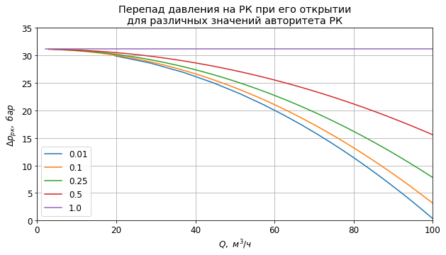

```python
import matplotlib.pyplot as plt
plt.rcParams['font.size'] = 12.0
fig, ax = plt.subplots(figsize = (10,5))
ax.set_xlim(0, Q_н_мин); ax.set_ylim(0, 35 )
ax.set_title('Перепад давления на РК при его открытии\nдля различных значений авторитета РК')
ax.plot(Qs, dps/1e5); ax.grid()
ax.set_xlabel('$Q,\ м^3/ч$'); ax.set_ylabel('$\Delta p_{рк},\ бар$')
ax.legend(ms);
```

```python
p1 = (H + h_к) * dens * g + p_к  #полное давление перед РК, Па
p1  # Па
```

```
3164075.5458285455
```

```python
# Статическое (полное за минусом динамического) давление
p1s = p1  - (Qs / F / 3600) ** 2 / 2 * dens # перед РК
p2s = p1s - dps  # за РК
```

```python
# Проверка: результат выражения должен быть ноль
# p2s[-1][-1] - статическое давление за открытым РК с авторитетеом m=1
p2s[-1][-1] - h_к * dens * g - p_к
```

```
2.051820047199726e-09
```

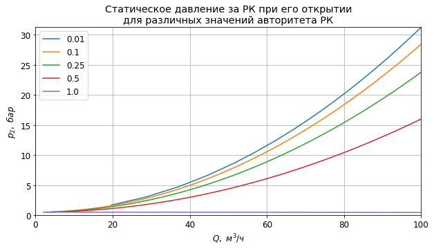

```python
fig, ax = plt.subplots(figsize = (10,5))
ax.set_xlim(0, Q_н_мин); ax.set_ylim(0, p2s[-1][0]/1e5)
ax.set_title('Статическое давление за РК при его открытии\nдля различных значений авторитета РК')
ax.plot(Qs, p2s/1e5); ax.grid()
ax.set_xlabel('$Q,\ м^3/ч$'); ax.set_ylabel('$p_{2},\ бар$')
ax.legend(ms);
```

```python
Kcs = (p1s - p2s)/(p1s - p_к)  # коэффициенты кавитации РК
```

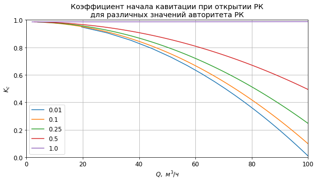

```python
fig, ax = plt.subplots(figsize = (10,5))
ax.set_xlim(0, Q_н_мин); ax.set_ylim(0, 1)
ax.set_title('Коэффициент начала кавитации при открытии РК\nдля различных значений авторитета РК')
ax.plot(Qs, Kcs); ax.grid()
ax.set_xlabel('$Q,\ м^3/ч$'); ax.set_ylabel('$K_{c}$')
ax.legend(ms);
```

Если принять для РК $K_c^{рк} = 0.8$, то минимальный допустимый расход в бескавитационном режиме работы через РК (с авторитетом $m = 0.1$) составит около 45 $м^3/ч$, т.е диапазон регулирования расхода в линии рециркуляции будет 45 - 100 $м^3/ч$.

Чтобы иметь возможность регулировать расход в линии рециркуляции в диапазоне 0 - 100 $м^3/ч$ необхождимо использовать РК, конструкция которого и применяемые при его производстве материалы позволяют работать в режиме кавитации.

Так же вместо РК можно установить в линию рециркуляции запорную арматуру. В этом случае у линии рецииркуляции будет два режима работы:

1. Линия открыта ($Q = 100\ м^3/ч$),
2. Линия закрыта ($Q = 0\ м^3/ч$).

Определим стоимость электроэнергии, затрачиваемой на перекачку конденсата через линию рециркуляции.

Потребляемая насосом электрическая мощность:

$$P = \frac{\rho g H q}{\eta}$$

$P$ - электрическая мощность, Вт; $\rho$ - плотность перекачиваемой жидкости, $кг/м^3$; $H$ - напор насоса, м; $q = Q/3600$ - подача насоса, $м^3/с$; $\eta$ - КПД насосного агрегата (насос + электродвигатель).

Определим электрическую мощность, потребляемую электродвигателем КЭН при расходе в линии рециркуляции $Q_{мин}$.

```python
КПД_н = 0.8  # КПД насосного агрегата
P = Q_н_мин / 3600 * H * dens * g / КПД_н
P  # Вт
```

```
108301.6305153822
```

```python
p = P / Q_н_мин / 1e3 # Мощность на перекачку 1 м3/ч, кВт/(м3/ч)
p
```

```
1.083016305153822
```

```python
Ц_э = 5 # стоимость электроэнергии, руб/(кВт*ч)
```

Прокачка по линии рециркуляции 1 $м^3/ч$ в течение одного часа обойдётся в

```python
p * Ц_э * 3600  # рублей/(м3/ч*ч)
```

```
19494.293492768797
```

## Выводы

В линию рециркуляции КЭН для регулирования в ней расхода можно установить (в порядке убывания капитальных затрат и увеличения эксплуатационных затрат):

1. РК с возможностью работы в режиме кавитации;
2. РК без возможности работы в режиме кавитации;
3. Запорную арматуру.

Так же можно рассмотреть покупку насоса с меньшим значением минимально допустимой подачи.

Выбор варианта зависит от стоимости арматуры, стоимости электроэнергии и общего времени в течение которого линия рециркуляции будет находиться в работе.

### Ссылки

1. [Расчёт теплофизических свойств воды и водяного пара](https://medsv.github.io/dzen/0033/hsdiag.html)
2. [Расчёт параметров регулирующего клапана](https://medsv.github.io/dzen/0029/Расчёт_параметров_РК.html)
3. [Расчёт дроссельной шайбы. Часть 1.](https://medsv.github.io/dzen/0021/orifice.html)

[Инженерные расчёты на Python](https://zen.yandex.ru/id/5f33dcd5554adc5b33aaee83), С.В. Медведев, 2020-2022  
Использование Python и Jupyter Notebook для инженерных расчётов, С.В. Медведев, 2020-2022